# Assessing top-k Recommender Systems: MAP@k and nDCG@k

A $top-k$ recommender system is an algorithm which, given a large list of potential items to recommend, is required to produce a reduced list of $k$ maximally relevant items to each user.

It is very useful to be able to summarise the performance of a model using a single-number summary. For example, we can summarise the performance of a regression model with the [mean squared error](https://en.wikipedia.org/wiki/Mean_squared_error) and [coefficient of determination $R^2$](https://en.wikipedia.org/wiki/Coefficient_of_determination), or the performance of a classication model with [accuracy](https://en.wikipedia.org/wiki/Confusion_matrix), [AUC](https://en.wikipedia.org/wiki/Receiver_operating_characteristic#Area_under_the_curve) and [F1 score](https://en.wikipedia.org/wiki/F-score).

What irritated me when I investigated these metrics for the first time was the lack of concrete examples of their implementation, so that is what I have given here - the calculations clearly laid out.

I’m happy that my calculations are correct - I am able to perfectly replicate the output of the [XG-Boost](https://github.com/dmlc/xgboost) package on these metrics ($MAP@k$ and $nDCG@k$).

It turns out that the definitions of these metrics **MAP@k** and **NDCG@k** differ somewhat by source, although they are all variations on the same theme (see, for example, [DCG](https://en.wikipedia.org/wiki/Discounted_cumulative_gain).

Some sources (e.g. the [XG-Boost](https://github.com/dmlc/xgboost) package and wikipedia) define the denominator of the $AP@k$ simply as $n$. I don’t think that this makes sense in the $top-k$ recommendations context: In my opinion, the ranking model should not be penalised where there are more than $k$ relevant items for a given user in the database, since we are not allowing the ranker to recommend more than $k$ items.

$nDCG@k$ is defined (for a single user) as:

$$\begin{array}{lcl}
nDCG@k &=& \displaystyle\frac{DCG@k}{\text{ideal } DCG@k} \\
DCG@k &=& \displaystyle\sum_{i=1}^k \displaystyle\frac{2^{y_i}-1}{log_2(i+1)} \\
y_i &=& \text{relevance of (gain from) the item in rank } i \\
\text{ideal } DCG@k &=& \text{the highest achievable } DCG@k \text{ on the observed data} \\
k &=& \text{number of items recommended to user} \\
\end{array}$$

So, $DCG@k$ (for a single user) is the sum of the relevance values of the highest ranked $k$ items, where the relevance values are discounted (shrunk) as they fall further down in the ranking. $nDCG@k$ is simply the relative size of the user’s $DCG@k$ value compared to the highest possible $DCG@k$ value, which we could have achieved if we had an item-ranking system with perfect knowledge.

NDCG@k

| Model 1 item_rank | Model 1 item_id | Model 1 relevant_to_user_1 | Model 1 CG@k | Model 1 DCG@k | Model 1 ideal_DCG@k | Model 1 NDCG@k | Model 2 item_rank | Model 2 item_id | Model 2 relevant_to_user_1 | Model 2 CG@k | Model 2 DCG@k | Model 2 NDCG@k |
| --- | --- | --- | --- | --- | --- | --- | --- | --- | --- | --- | --- | --- |
| 1 | 5 | 1 | 1 | 1.000 | 1.000 | 1.000 | 1 | 15 | 0 | 0 | 0.000 | 0.000 |
| 2 | 16 | 1 | 2 | 1.631 | 1.631 | 1.000 | 2 | 13 | 0 | 0 | 0.000 | 0.000 |
| 3 | 11 | 0 | 2 | 1.631 | 2.131 | 0.765 | 3 | 8 | 1 | 1 | 0.500 | 0.235 |
| 4 | 8 | 1 | 3 | 2.062 | 2.562 | 0.805 | 4 | 11 | 0 | 1 | 0.500 | 0.195 |
| 5 | 4 | 1 | 4 | 2.448 | 2.948 | 0.830 | 5 | 1 | 0 | 1 | 0.500 | 0.170 |
| 6 | 12 | 0 | 4 | 2.448 | 3.305 | 0.741 | 6 | 5 | 1 | 2 | 0.856 | 0.259 |
| 7 | 9 | 1 | 5 | 2.782 | 3.638 | 0.765 | 7 | 12 | 0 | 2 | 0.856 | 0.235 |
| 8 | 15 | 0 | 5 | 2.782 | 3.638 | 0.765 | 8 | 16 | 1 | 3 | 1.172 | 0.322 |
| 9 | 1 | 0 | 5 | 2.782 | 3.638 | 0.765 | 9 | 14 | 1 | 4 | 1.473 | 0.405 |
| 10 | 7 | 0 | 5 | 2.782 | 3.638 | 0.765 | 10 | 2 | 0 | 4 | 1.473 | 0.405 |
| 11 | 10 | 1 | 6 | 3.061 | 3.638 | 0.841 | 11 | 6 | 0 | 4 | 1.473 | 0.405 |
| 12 | 13 | 0 | 6 | 3.061 | 3.638 | 0.841 | 12 | 10 | 1 | 5 | 1.743 | 0.479 |
| 13 | 3 | 0 | 6 | 3.061 | 3.638 | 0.841 | 13 | 7 | 0 | 5 | 1.743 | 0.479 |
| 14 | 14 | 1 | 7 | 3.317 | 3.638 | 0.912 | 14 | 3 | 0 | 5 | 1.743 | 0.479 |
| 15 | 2 | 0 | 7 | 3.317 | 3.638 | 0.912 | 15 | 4 | 1 | 6 | 1.993 | 0.548 |
| 16 | 6 | 0 | 7 | 3.317 | 3.638 | 0.912 | 16 | 9 | 1 | 7 | 2.238 | 0.615 |

AP@k

| Model 1 item_rank | Model 1 item_id | Model 1 relevant_to_user_1 | Model 1 precision | Model 1 recall | Model 1 Average_Precision | Model 2 item_rank | Model 2 item_id | Model 2 relevant_to_user_1 | Model 2 precision | Model 2 recall | Model 2 Average_Precision |
| --- | --- | --- | --- | --- | --- | --- | --- | --- | --- | --- | --- |
| 1 | 5 | 1 | 1.000 | 0.143 | 0.143 | 1 | 15 | 0 | 0.000 | 0.000 | 0.000 |
| 2 | 16 | 1 | 1.000 | 0.286 | 0.286 | 2 | 13 | 0 | 0.000 | 0.000 | 0.000 |
| 3 | 11 | 0 | 0.667 | 0.286 | 0.286 | 3 | 8 | 1 | 0.333 | 0.143 | 0.048 |
| 4 | 8 | 1 | 0.750 | 0.429 | 0.393 | 4 | 11 | 0 | 0.250 | 0.143 | 0.048 |
| 5 | 4 | 1 | 0.800 | 0.571 | 0.507 | 5 | 1 | 0 | 0.200 | 0.143 | 0.048 |
| 6 | 12 | 0 | 0.667 | 0.571 | 0.507 | 6 | 5 | 1 | 0.333 | 0.286 | 0.095 |
| 7 | 9 | 1 | 0.714 | 0.714 | 0.609 | 7 | 12 | 0 | 0.286 | 0.286 | 0.095 |
| 8 | 15 | 0 | 0.625 | 0.714 | 0.609 | 8 | 16 | 1 | 0.375 | 0.429 | 0.149 |
| 9 | 1 | 0 | 0.556 | 0.714 | 0.609 | 9 | 14 | 1 | 0.444 | 0.571 | 0.212 |
| 10 | 7 | 0 | 0.500 | 0.714 | 0.609 | 10 | 2 | 0 | 0.400 | 0.571 | 0.212 |
| 11 | 10 | 1 | 0.545 | 0.857 | 0.687 | 11 | 6 | 0 | 0.364 | 0.571 | 0.212 |
| 12 | 13 | 0 | 0.500 | 0.857 | 0.687 | 12 | 10 | 1 | 0.417 | 0.714 | 0.272 |
| 13 | 3 | 0 | 0.462 | 0.857 | 0.687 | 13 | 7 | 0 | 0.385 | 0.714 | 0.272 |
| 14 | 14 | 1 | 0.500 | 1.000 | 0.759 | 14 | 3 | 0 | 0.357 | 0.714 | 0.272 |
| 15 | 2 | 0 | 0.467 | 1.000 | 0.759 | 15 | 4 | 1 | 0.400 | 0.857 | 0.329 |
| 16 | 6 | 0 | 0.438 | 1.000 | 0.759 | 16 | 9 | 1 | 0.438 | 1.000 | 0.391 |

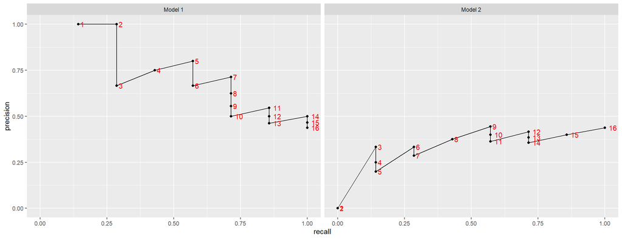